# Referrals to secondary care in Rio de Janeiro from 2013 to 2018

A total number of 142,718 referrals to any type of health care specialty. Patients where categorized according to the Family Health Team they are enrolled. Every Family Health Team was categorized according to the type of doctor in charge, i.e., Family Physician or Generalist.

| Type of doctor | Number of visits | Number of patients referred | Referred patients (%) | Referred Consultations (%) | Referred Exams (%) |
| --- | --- | --- | --- | --- | --- |
| Generalist | 464832 | 87857 | 23.4 | 45.56 | 54.44 |
| FP | 433638 | 54861 | 15.6 | 44.68 | 55.34 |

## Risk of being referred according to the type of doctor at the Family Health Team

At the following Poisson regression model the risk for being referred was estimated based on the type of doctor in the FHT and adjusted by the Social Development Index and the number of pregnant women doing pre-natal care at the clinic.

Poisson regression models for referrals to secondary care according to the type of doctor in the Family Health Team, social development index and the number of pregnant women doing pre-natal care at the clinic. Rio de Janeiro, 2013 to 2018

Model.1

Model.2

Model.3

Predictors

IRR

IRR

IRR

Family Physician

0.67 ***  
(0.66 – 0.68)

0.67 ***  
(0.66 – 0.68)

0.69 ***  
(0.69 – 0.70)

Social Development Index

1.90 ***  
(1.66 – 2.18)

1.57 ***  
(1.37 – 1.80)

Number of pregnant women

0.99 ***  
(0.99 – 1.00)

Observations

467880

467880

467880

- p<0.05 ** p<0.01 *** p<0.001

In every 100 consultations Generalists sent 23.4 patients to see a specialist in the secondary level of care versus 15.6 by Family Physicians. This 8% difference is seen in almost every kind of specialist in the secondary level of care, but this gap can be bigger or smaller depending on the type of specialty requested. The following regression models will explore this caracteristics.

## Poisson regression models calculating the Incidence Rate Ratio for a patient to be referred to secondary care regarding to the type of doctor in Primary Care.

Every model was adjusted to the Social Development Index of the catchement area of the FHT and to the number of pregnant women doing prenatal care during the period.

The Social Development Index is a summary indicator combining information about age pyramid, education, wealth of the population living in the area, as well as urban conditions such as sanitation and garbage collection.

The number of pregnant women going to prenatal care at the clinic was used to add information about the amount of work the FHT has to deal with a protocolar health care program. Usually doctors in primary care complain about the workload with prenatal care and child care, leaving them with no free time to dedicate for patients with chronic conditions other than Hypertension, Type 2 diabetes or Tuberculosis.

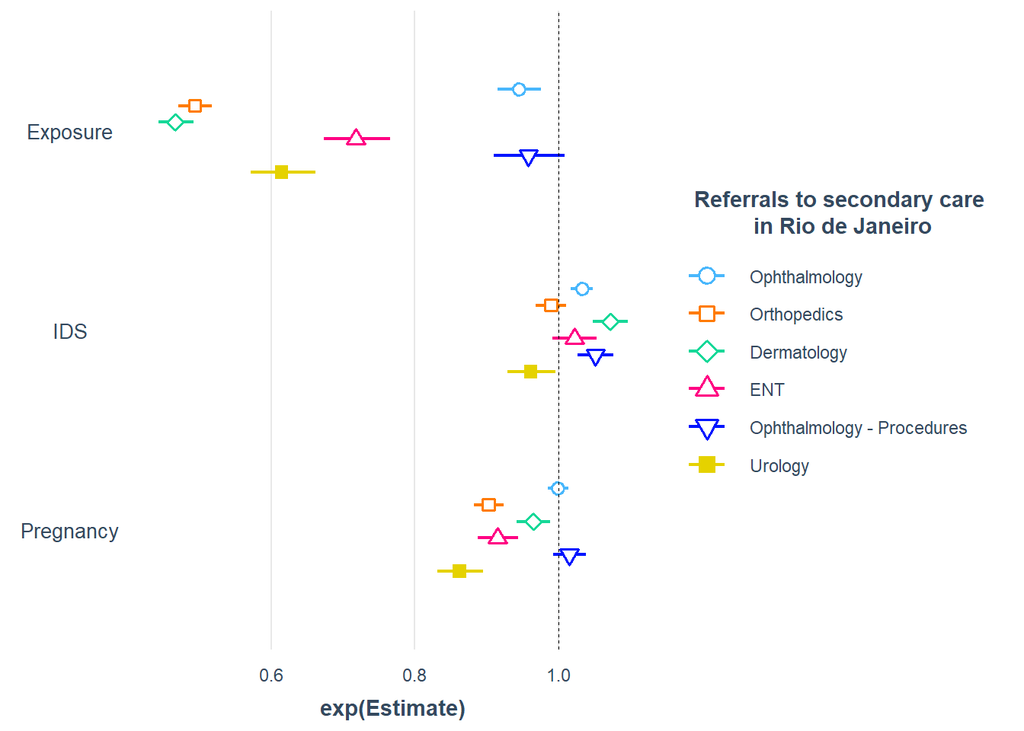

Health conditions that need equipments to be correctly diagnosed don’t show a big difference between Family Physicians and Generalists, such as Ophthalmology or Ophthalmological Procedures.

Poisson regression models for referrals to secondary care according to the type of doctor in the Family Health Team, social development index and the number of pregnant women doing pre-natal care at the clinic. Rio de Janeiro, 2013 to 2018

Ophthalmology

Orthopedics

Dermatology

ENT

Ophthalmology - Procedures

Urology

Predictors

IRR

IRR

IRR

IRR

IRR

IRR

Family Physician

0.95 ***  
(0.92 – 0.98)

0.49 ***  
(0.47 – 0.52)

0.47 ***  
(0.44 – 0.49)

0.72 ***  
(0.67 – 0.77)

0.96  
(0.91 – 1.01)

0.62 ***  
(0.57 – 0.66)

Social Development Index

2.36 ***  
(1.57 – 3.53)

0.76  
(0.43 – 1.35)

6.41 ***  
(3.48 – 11.77)

1.80  
(0.81 – 4.00)

3.82 ***  
(2.01 – 7.23)

0.35 *  
(0.14 – 0.90)

Number of pregnant women

1.00  
(1.00 – 1.00)

0.99 ***  
(0.99 – 0.99)

1.00 **  
(0.99 – 1.00)

0.99 ***  
(0.99 – 0.99)

1.00  
(1.00 – 1.00)

0.99 ***  
(0.98 – 0.99)

Observations

3342

3342

3342

3342

3342

3342

- p<0.05 ** p<0.01 *** p<0.001

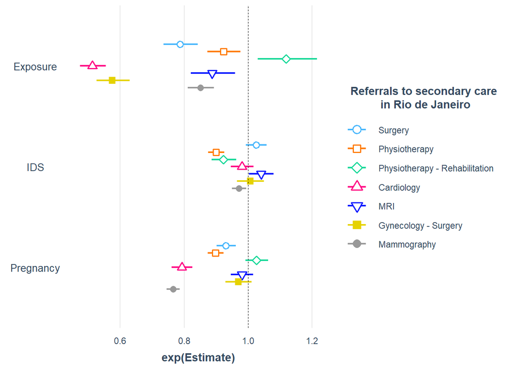

Plastic Surgery, another problem that doesn’t require too much knowledge to be diagnosed, but requires an specialist to solve the problem, doesn’t show a significative difference between Family Physicians and Generalists.

Poisson regression models for referrals to secondary care according to the type of doctor in the Family Health Team, social development index and the number of pregnant women doing pre-natal care at the clinic. Rio de Janeiro, 2013 to 2018

Surgery

Physiotherapy

Physiotherapy - Rehabilitation

Cardiology

MRI

Gynecology - Surgery

Mammography

Predictors

IRR

IRR

IRR

IRR

IRR

IRR

IRR

Family Physician

0.79 ***  
(0.74 – 0.84)

0.92 **  
(0.87 – 0.98)

1.12 **  
(1.03 – 1.22)

0.51 ***  
(0.47 – 0.55)

0.89 **  
(0.82 – 0.96)

0.57 ***  
(0.53 – 0.63)

0.85 ***  
(0.81 – 0.89)

Social Development Index

1.93  
(0.82 – 4.50)

0.06 ***  
(0.03 – 0.13)

0.12 ***  
(0.04 – 0.35)

0.59  
(0.23 – 1.54)

2.88 *  
(1.07 – 7.64)

1.19  
(0.39 – 3.58)

0.46 *  
(0.25 – 0.86)

Number of pregnant women

0.99 ***  
(0.99 – 1.00)

0.99 ***  
(0.99 – 0.99)

1.00  
(1.00 – 1.01)

0.98 ***  
(0.97 – 0.98)

1.00  
(0.99 – 1.00)

1.00  
(0.99 – 1.00)

0.97 ***  
(0.97 – 0.98)

Observations

3342

3342

3342

3342

3342

3342

3342

- p<0.05 ** p<0.01 *** p<0.001

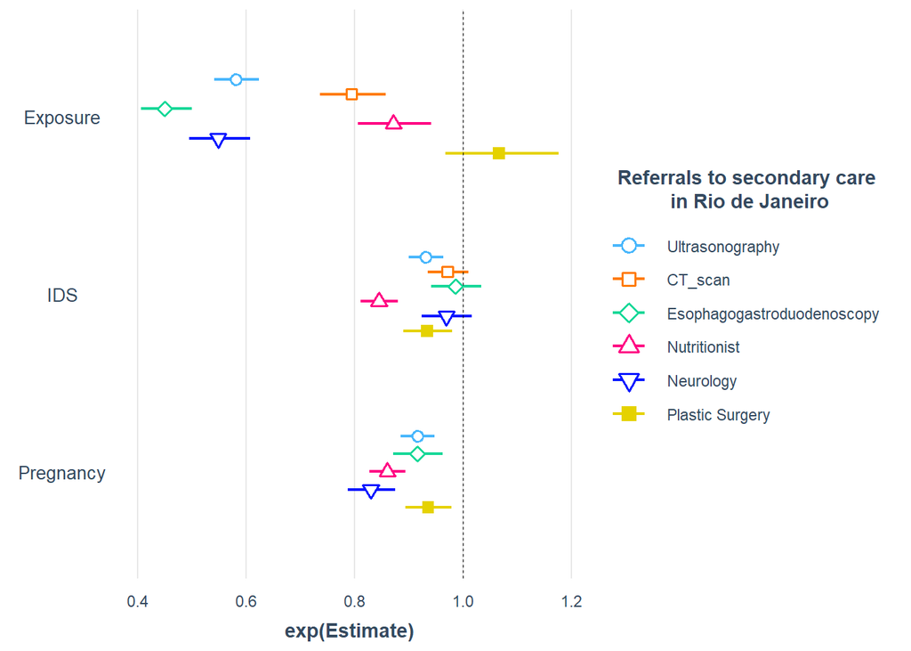

Referrals to Psychiatrist show the biggest difference between Fmaily Physicians and Generalists, probably because of the supervision of Psychiatrists provided by the Residency Programs to their residents.

Poisson regression models for referrals to secondary care according to the type of doctor in the Family Health Team, social development index and the number of pregnant women doing pre-natal care at the clinic. Rio de Janeiro, 2013 to 2018

Ultrasonography

CT_scan

Esophagogastroduodenoscopy

Nutritionist

Neurology

Plastic Surgery

Predictors

IRR

IRR

IRR

IRR

IRR

IRR

Family Physician

0.58 ***  
(0.54 – 0.62)

0.79 ***  
(0.74 – 0.86)

0.45 ***  
(0.41 – 0.50)

0.87 ***  
(0.81 – 0.94)

0.55 ***  
(0.49 – 0.61)

1.07  
(0.97 – 1.18)

Social Development Index

0.15 ***  
(0.06 – 0.36)

0.46  
(0.16 – 1.26)

0.68  
(0.19 – 2.35)

0.01 ***  
(0.00 – 0.03)

0.43  
(0.12 – 1.51)

0.16 **  
(0.04 – 0.58)

Number of pregnant women

0.99 ***  
(0.99 – 0.99)

0.99 ***  
(0.99 – 1.00)

0.99 ***  
(0.98 – 0.99)

0.98 ***  
(0.98 – 0.99)

0.99 **  
(0.99 – 1.00)

Observations

3342

3342

3342

3342

3342

3342

- p<0.05 ** p<0.01 *** p<0.001

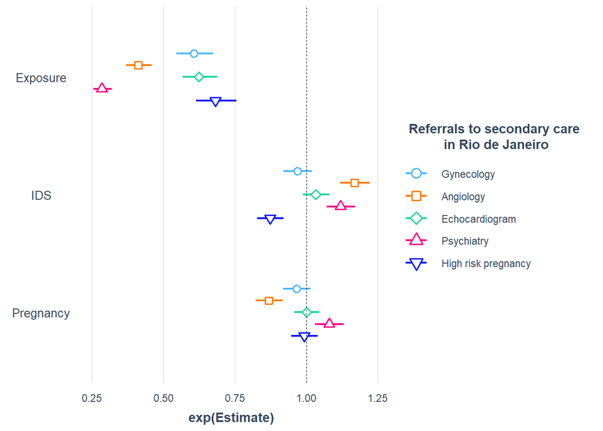

Poisson regression models for referrals to secondary care according to the type of doctor in the Family Health Team, social development index and the number of pregnant women doing pre-natal care at the clinic. Rio de Janeiro, 2013 to 2018

Gynecology

Angiology

Echocardiogram

Psychiatry

High risk pregnancy

Predictors

IRR

IRR

IRR

IRR

IRR

Family Physician

0.61 ***  
(0.54 – 0.67)

0.41 ***  
(0.37 – 0.46)

0.62 ***  
(0.57 – 0.69)

0.28 ***  
(0.25 – 0.32)

0.68 ***  
(0.61 – 0.76)

Social Development Index

0.42  
(0.11 – 1.59)

62.81 ***  
(18.90 – 205.89)

2.35  
(0.70 – 7.74)

20.20 ***  
(6.20 – 64.87)

0.03 ***  
(0.01 – 0.11)

Number of pregnant women

1.00  
(0.99 – 1.00)

0.99 ***  
(0.98 – 0.99)

1.00  
(1.00 – 1.00)

1.01 **  
(1.00 – 1.01)

1.00  
(0.99 – 1.00)

Observations

3342

3342

3342

3342

3342

- p<0.05 ** p<0.01 *** p<0.001

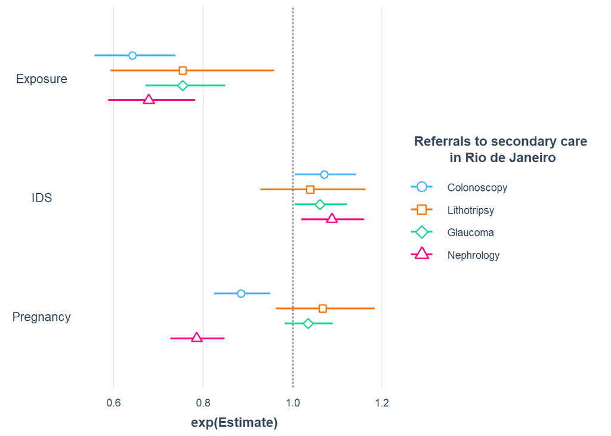

Poisson regression models for referrals to secondary care according to the type of doctor in the Family Health Team, social development index and the number of pregnant women doing pre-natal care at the clinic. Rio de Janeiro, 2013 to 2018

Colonoscopy

Lithotripsy

Glaucoma

Nephrology

Predictors

IRR

IRR

IRR

IRR

Family Physician

0.64 ***  
(0.56 – 0.74)

0.75 *  
(0.59 – 0.96)

0.75 ***  
(0.67 – 0.85)

0.68 ***  
(0.59 – 0.78)

Social Development Index

6.21 *  
(1.10 – 33.94)

2.79  
(0.13 – 53.82)

4.91 *  
(1.12 – 20.92)

9.42 *  
(1.65 – 52.32)

Number of pregnant women

0.99 ***  
(0.98 – 0.99)

1.01  
(1.00 – 1.02)

1.00  
(1.00 – 1.01)

0.98 ***  
(0.97 – 0.98)

Observations

3342

3342

3342

3342

- p<0.05 ** p<0.01 *** p<0.001